# 🚗 Monthly Car Sales Forecasting

## Time Series Forecasting using SARIMA

### 📊 Predicting Future Monthly Car Sales

**Prepared by:** Lovisha Jaat  
**Algorithm:** Seasonal ARIMA  
**Dataset:** Monthly Car Sales Dataset

## 🎯 1. Problem Statement

Automobile companies need accurate sales forecasts to manage production, inventory, staffing and marketing strategies.

The objective of this notebook is to build a **SARIMA time-series forecasting model** that predicts future monthly car sales using historical sales data.

SARIMA is suitable for this problem because monthly car sales may contain:

- Long-term trends
- Repeating yearly seasonality
- Autocorrelation between observations
- Changes in sales over time

## 📂 2. Dataset Description

We will use the **Monthly Car Sales Dataset**.

### Dataset features

- **Month:** Month of recorded sales
- **Sales:** Number of cars sold during the month
- **Frequency:** Monthly
- **Forecasting target:** Monthly car sales

This is a univariate time-series dataset because one numerical variable, Sales, is forecast using its previous observations.

## 📦 3. Import Required Libraries

The following libraries are used for:

- Data manipulation
- Numerical operations
- Time-series visualization
- Stationarity testing
- Seasonal decomposition
- SARIMA model building
- Model evaluation

```python
import warnings
warnings.filterwarnings("ignore")

import pandas as pd
import numpy as np
import matplotlib.pyplot as plt

from statsmodels.tsa.stattools import adfuller
from statsmodels.tsa.seasonal import seasonal_decompose
from statsmodels.tsa.statespace.sarimax import SARIMAX

from sklearn.metrics import (
    mean_absolute_error,
    mean_squared_error
)
```

## 📥 4. Dataset Loading

The Monthly Car Sales Dataset is loaded directly from a public repository.

After loading the dataset, we will examine its first few observations.

```python
url = "https://raw.githubusercontent.com/jbrownlee/Datasets/master/monthly-car-sales.csv"

df = pd.read_csv(url)

df.head()
```

|  | Month | Sales |
| --- | --- | --- |
| 0 | 1960-01 | 6550 |
| 1 | 1960-02 | 8728 |
| 2 | 1960-03 | 12026 |
| 3 | 1960-04 | 14395 |
| 4 | 1960-05 | 14587 |

## 🔍 5. Initial Dataset Inspection

Before building the forecasting model, we will inspect:

- Dataset dimensions
- Column names
- Data types
- Missing values
- Statistical summary

```python
print("Dataset Shape:", df.shape)

print("\nColumn Names:")
print(df.columns.tolist())

print("\nData Types:")
print(df.dtypes)

print("\nMissing Values:")
print(df.isnull().sum())

print("\nStatistical Summary:")
display(df.describe())
```

```
Dataset Shape: (108, 2)

Column Names:
['Month', 'Sales']

Data Types:
Month    object
Sales     int64
dtype: object

Missing Values:
Month    0
Sales    0
dtype: int64

Statistical Summary:
```

|  | Sales |
| --- | --- |
| count | 108.000000 |
| mean | 14595.111111 |
| std | 4525.213913 |
| min | 5568.000000 |
| 25% | 11391.250000 |
| 50% | 14076.000000 |
| 75% | 17595.750000 |
| max | 26099.000000 |

## 🛠️ 6. Data Preprocessing

Time-series models require observations to be arranged in chronological order.

In this step, we will:

1. Convert the Month column to datetime format
2. Set Month as the DataFrame index
3. Assign monthly-start frequency
4. Sort observations by date
5. Check missing values

```python
df["Month"] = pd.to_datetime(df["Month"])

df.set_index("Month", inplace=True)

df.sort_index(inplace=True)

df = df.asfreq("MS")

df.head()
```

| Month | Sales |
| --- | --- |
| 1960-01-01 | 6550 |
| 1960-02-01 | 8728 |
| 1960-03-01 | 12026 |
| 1960-04-01 | 14395 |
| 1960-05-01 | 14587 |

```python
print("Starting Date:", df.index.min())
print("Ending Date:", df.index.max())
print("Time-Series Frequency:", df.index.freq)
print("Total Observations:", len(df))
print("Missing Values:", df["Sales"].isnull().sum())
```

```
Starting Date: 1960-01-01 00:00:00
Ending Date: 1968-12-01 00:00:00
Time-Series Frequency: <MonthBegin>
Total Observations: 108
Missing Values: 0
```

## 🧹 7. Handling Missing Values

Missing observations can interrupt the continuity of a time series.

If missing sales values are found, time-based interpolation will be used to estimate them from nearby observations.

```python
if df["Sales"].isnull().sum() > 0:
    df["Sales"] = df["Sales"].interpolate(method="time")

print("Missing Values After Processing:", df["Sales"].isnull().sum())
```

```
Missing Values After Processing: 0
```

## 📈 8. Historical Sales Visualization

The time-series graph helps us identify:

- General sales trend
- Seasonal patterns
- Sudden increases or decreases
- Variation in monthly car sales

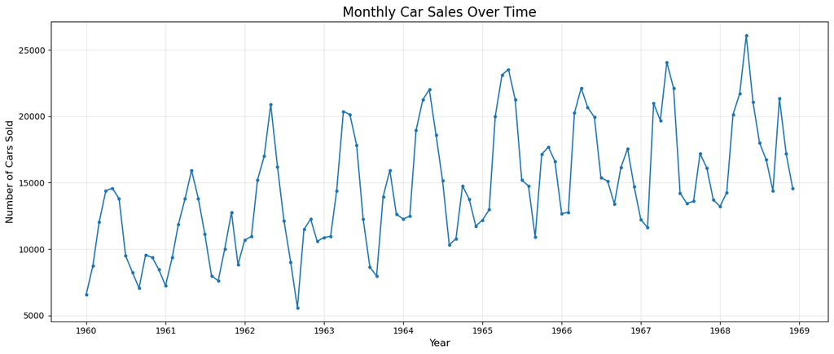

```python
plt.figure(figsize=(14, 6))

plt.plot(
    df.index,
    df["Sales"],
    marker="o",
    markersize=3,
    linewidth=1.5
)

plt.title("Monthly Car Sales Over Time", fontsize=16)
plt.xlabel("Year", fontsize=12)
plt.ylabel("Number of Cars Sold", fontsize=12)
plt.grid(alpha=0.3)
plt.tight_layout()
plt.show()
```

## 📊 9. Rolling Mean and Rolling Standard Deviation

Rolling statistics help us understand whether the statistical properties of the series change over time.

We will calculate:

- 12-month rolling mean
- 12-month rolling standard deviation

A 12-month window is used because the dataset has monthly observations and may contain yearly seasonality.

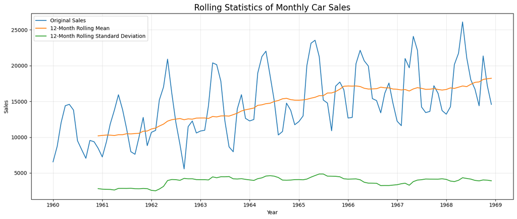

```python
rolling_mean = df["Sales"].rolling(window=12).mean()
rolling_std = df["Sales"].rolling(window=12).std()

plt.figure(figsize=(14, 6))

plt.plot(df["Sales"], label="Original Sales")
plt.plot(rolling_mean, label="12-Month Rolling Mean")
plt.plot(rolling_std, label="12-Month Rolling Standard Deviation")

plt.title("Rolling Statistics of Monthly Car Sales", fontsize=16)
plt.xlabel("Year")
plt.ylabel("Sales")
plt.legend()
plt.grid(alpha=0.3)
plt.tight_layout()
plt.show()
```

## 🧩 10. Seasonal Decomposition

Seasonal decomposition separates a time series into four components:

- **Observed:** Original time-series values
- **Trend:** Long-term movement
- **Seasonal:** Repeating pattern
- **Residual:** Unexplained variation

Because the data is monthly, we use a seasonal period of **12 months**.

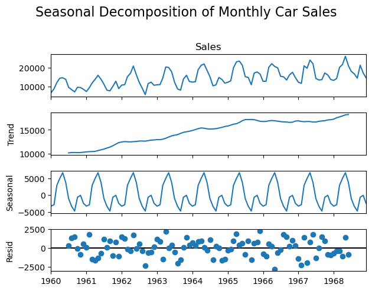

```python
decomposition = seasonal_decompose(
    df["Sales"],
    model="additive",
    period=12
)

decomposition.plot()
plt.suptitle(
    "Seasonal Decomposition of Monthly Car Sales",
    fontsize=16,
    y=1.02
)
plt.tight_layout()
plt.show()
```

## 🧪 11. Stationarity Testing

SARIMA performs better when the time series is stationary.

A stationary series has relatively stable:

- Mean
- Variance
- Autocorrelation structure

We will use the **Augmented Dickey-Fuller Test**.

### Hypotheses

- **Null hypothesis:** The series is non-stationary
- **Alternative hypothesis:** The series is stationary

If the p-value is less than `0.05`, the series is considered stationary.

```python
def adf_test(series):
    result = adfuller(series.dropna())

    print("ADF Statistic:", result[0])
    print("P-value:", result[1])
    print("Number of Lags:", result[2])
    print("Number of Observations:", result[3])

    print("\nCritical Values:")
    for key, value in result[4].items():
        print(f"{key}: {value}")

    if result[1] <= 0.05:
        print("\nConclusion: The time series is stationary.")
    else:
        print("\nConclusion: The time series is non-stationary.")
```

```python
adf_test(df["Sales"])
```

```
ADF Statistic: -1.2238127661752842
P-value: 0.6632691049832867
Number of Lags: 12
Number of Observations: 95

Critical Values:
1%: -3.5011373281819504
5%: -2.8924800524857854
10%: -2.5832749307479226

Conclusion: The time series is non-stationary.
```

## 🔄 12. Differencing the Time Series

If the original series is non-stationary, differencing can help stabilize it.

We will calculate:

- First-order difference for removing trend
- Seasonal difference of 12 months for removing yearly seasonality

The SARIMA model can also perform these differencing operations internally.

```python
df["First_Difference"] = df["Sales"].diff()

df["Seasonal_Difference"] = df["Sales"].diff(12)

df.head(15)
```

| Month | Sales | First_Difference | Seasonal_Difference |
| --- | --- | --- | --- |
| 1960-01-01 | 6550 | NaN | NaN |
| 1960-02-01 | 8728 | 2178.0 | NaN |
| 1960-03-01 | 12026 | 3298.0 | NaN |
| 1960-04-01 | 14395 | 2369.0 | NaN |
| 1960-05-01 | 14587 | 192.0 | NaN |
| 1960-06-01 | 13791 | -796.0 | NaN |
| 1960-07-01 | 9498 | -4293.0 | NaN |
| 1960-08-01 | 8251 | -1247.0 | NaN |
| 1960-09-01 | 7049 | -1202.0 | NaN |
| 1960-10-01 | 9545 | 2496.0 | NaN |
| 1960-11-01 | 9364 | -181.0 | NaN |
| 1960-12-01 | 8456 | -908.0 | NaN |
| 1961-01-01 | 7237 | -1219.0 | 687.0 |
| 1961-02-01 | 9374 | 2137.0 | 646.0 |
| 1961-03-01 | 11837 | 2463.0 | -189.0 |

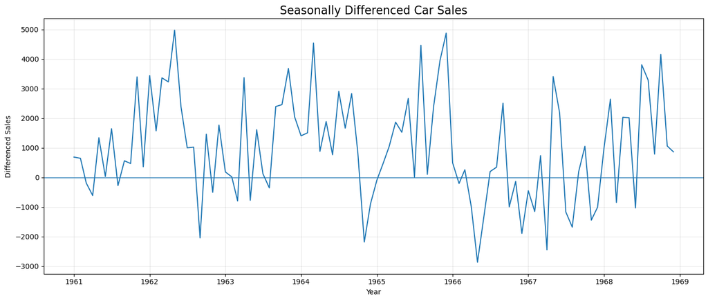

```python
plt.figure(figsize=(14, 6))

plt.plot(df.index, df["Seasonal_Difference"])

plt.title("Seasonally Differenced Car Sales", fontsize=16)
plt.xlabel("Year")
plt.ylabel("Differenced Sales")
plt.axhline(y=0, linewidth=1)
plt.grid(alpha=0.3)
plt.tight_layout()
plt.show()
```

```python
adf_test(df["Seasonal_Difference"])
```

```
ADF Statistic: -3.644396602406013
P-value: 0.004966833586579766
Number of Lags: 11
Number of Observations: 84

Critical Values:
1%: -3.510711795769895
5%: -2.8966159448223734
10%: -2.5854823866213152

Conclusion: The time series is stationary.
```

## ✂️ 13. Train-Test Split

Time-series data must not be randomly shuffled because chronological order is important.

We will use:

- All observations except the final 12 months for training
- The final 12 months for testing

The testing period represents one complete seasonal cycle.

```python
series = df["Sales"]

train = series.iloc[:-12]
test = series.iloc[-12:]

print("Training Observations:", len(train))
print("Testing Observations:", len(test))

print("\nTraining Period:")
print(train.index.min(), "to", train.index.max())

print("\nTesting Period:")
print(test.index.min(), "to", test.index.max())
```

```
Training Observations: 96
Testing Observations: 12

Training Period:
1960-01-01 00:00:00 to 1967-12-01 00:00:00

Testing Period:
1968-01-01 00:00:00 to 1968-12-01 00:00:00
```

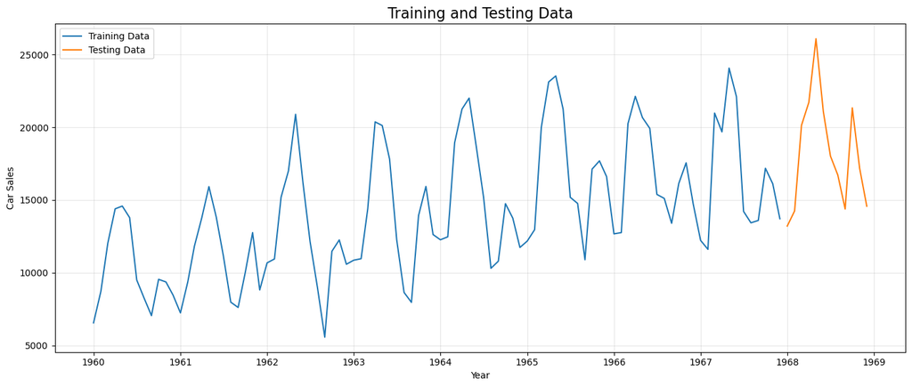

```python
plt.figure(figsize=(14, 6))

plt.plot(train.index, train, label="Training Data")
plt.plot(test.index, test, label="Testing Data")

plt.title("Training and Testing Data", fontsize=16)
plt.xlabel("Year")
plt.ylabel("Car Sales")
plt.legend()
plt.grid(alpha=0.3)
plt.tight_layout()
plt.show()
```

## 🤖 14. SARIMA Model Building

SARIMA stands for:

**Seasonal AutoRegressive Integrated Moving Average**

The model contains two groups of parameters.

### Non-seasonal parameters: `(p, d, q)`

- `p`: Number of autoregressive terms
- `d`: Number of differences
- `q`: Number of moving-average terms

### Seasonal parameters: `(P, D, Q, s)`

- `P`: Seasonal autoregressive terms
- `D`: Seasonal differences
- `Q`: Seasonal moving-average terms
- `s`: Number of observations in one seasonal cycle

For monthly data:

`s = 12`

We will use:

- `order = (1, 1, 1)`
- `seasonal_order = (1, 1, 1, 12)`

```python
sarima_model = SARIMAX(
    train,
    order=(1, 1, 1),
    seasonal_order=(1, 1, 1, 12),
    enforce_stationarity=False,
    enforce_invertibility=False
)
```

## 🏋️ 15. Model Training

The SARIMA model will now learn:

- Relationships with previous months
- Trend changes
- Seasonal differences
- Repeating yearly patterns

```python
sarima_result = sarima_model.fit(disp=False)

print(sarima_result.summary())
```

```
                                     SARIMAX Results
==========================================================================================
Dep. Variable:                              Sales   No. Observations:                   96
Model:             SARIMAX(1, 1, 1)x(1, 1, 1, 12)   Log Likelihood                -608.288
Date:                            Sat, 11 Jul 2026   AIC                           1226.575
Time:                                    23:29:46   BIC                           1237.746
Sample:                                01-01-1960   HQIC                          1231.007
                                     - 12-01-1967
Covariance Type:                              opg
==============================================================================
                 coef    std err          z      P>|z|      [0.025      0.975]
------------------------------------------------------------------------------
ar.L1          0.2107      0.207      1.019      0.308      -0.194       0.616
ma.L1         -0.8725      0.108     -8.044      0.000      -1.085      -0.660
ar.S.L12      -0.2730      0.335     -0.815      0.415      -0.929       0.383
ma.S.L12      -0.1750      0.364     -0.480      0.631      -0.889       0.539
sigma2      3.256e+06   7.43e+05      4.381      0.000     1.8e+06    4.71e+06
===================================================================================
Ljung-Box (L1) (Q):                   0.11   Jarque-Bera (JB):                 0.29
Prob(Q):                              0.75   Prob(JB):                         0.86
Heteroskedasticity (H):               1.10   Skew:                             0.14
Prob(H) (two-sided):                  0.82   Kurtosis:                         2.84
===================================================================================

Warnings:
[1] Covariance matrix calculated using the outer product of gradients (complex-step).
```

## 🔬 16. Model Diagnostics

Diagnostic plots help determine whether model residuals behave like random noise.

A suitable model should generally have:

- Residuals centred near zero
- No major repeating pattern
- Approximately normal residual distribution
- Limited remaining autocorrelation

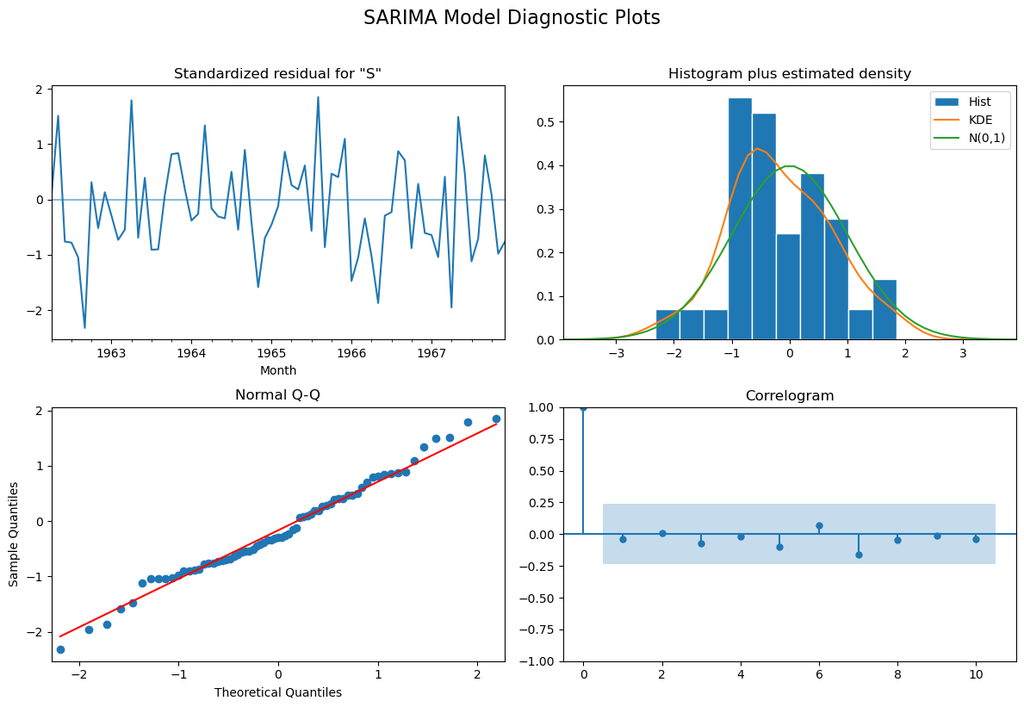

```python
sarima_result.plot_diagnostics(figsize=(12, 8))
plt.suptitle("SARIMA Model Diagnostic Plots", fontsize=16, y=1.02)
plt.tight_layout()
plt.show()
```

## 🔮 17. Forecasting the Testing Period

The trained model will forecast the same number of months available in the testing dataset.

This allows us to compare forecasted sales with actual sales.

```python
forecast_result = sarima_result.get_forecast(steps=len(test))

forecast = forecast_result.predicted_mean

confidence_interval = forecast_result.conf_int()

forecast.index = test.index
confidence_interval.index = test.index

forecast.head()
```

```
Month
1968-01-01    12054.625145
1968-02-01    12041.162230
1968-03-01    20572.397985
1968-04-01    20807.884656
1968-05-01    22730.703356
Freq: MS, Name: predicted_mean, dtype: float64
```

## 📉 18. Forecast Visualization

The following graph compares:

- Training observations
- Actual testing values
- SARIMA forecasts
- Forecast confidence interval

The confidence interval represents the expected range of uncertainty around the forecast.

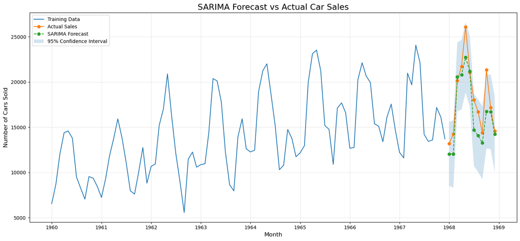

```python
plt.figure(figsize=(15, 7))

plt.plot(
    train.index,
    train,
    label="Training Data"
)

plt.plot(
    test.index,
    test,
    marker="o",
    label="Actual Sales"
)

plt.plot(
    forecast.index,
    forecast,
    marker="o",
    linestyle="--",
    label="SARIMA Forecast"
)

plt.fill_between(
    confidence_interval.index,
    confidence_interval.iloc[:, 0],
    confidence_interval.iloc[:, 1],
    alpha=0.2,
    label="95% Confidence Interval"
)

plt.title("SARIMA Forecast vs Actual Car Sales", fontsize=17)
plt.xlabel("Month", fontsize=12)
plt.ylabel("Number of Cars Sold", fontsize=12)
plt.legend()
plt.grid(alpha=0.3)
plt.tight_layout()
plt.show()
```

## 📏 19. Model Evaluation

The SARIMA forecasts will be evaluated using:

### Mean Absolute Error

MAE calculates the average absolute difference between actual and forecasted values.

### Root Mean Squared Error

RMSE gives more importance to larger prediction errors.

### Mean Absolute Percentage Error

MAPE expresses the average forecast error as a percentage.

Lower values of MAE, RMSE and MAPE indicate better forecasting performance.

```python
mae = mean_absolute_error(test, forecast)

rmse = np.sqrt(
    mean_squared_error(test, forecast)
)

mape = np.mean(
    np.abs((test.values - forecast.values) / test.values)
) * 100

print("SARIMA Model Evaluation")
print("-" * 35)
print(f"MAE  : {mae:.2f}")
print(f"RMSE : {rmse:.2f}")
print(f"MAPE : {mape:.2f}%")
```

```
SARIMA Model Evaluation
-----------------------------------
MAE  : 1725.11
RMSE : 2226.98
MAPE : 9.40%
```

## 📋 20. Actual and Forecasted Values

The following table provides a month-by-month comparison between actual and forecasted car sales.

The forecast error is also calculated for easier interpretation.

```python
results = pd.DataFrame({
    "Actual Sales": test,
    "Forecasted Sales": forecast
})

results["Absolute Error"] = abs(
    results["Actual Sales"] - results["Forecasted Sales"]
)

results["Percentage Error"] = (
    results["Absolute Error"] / results["Actual Sales"]
) * 100

results.round(2)
```

| Month | Actual Sales | Forecasted Sales | Absolute Error | Percentage Error |
| --- | --- | --- | --- | --- |
| 1968-01-01 | 13210 | 12054.63 | 1155.37 | 8.75 |
| 1968-02-01 | 14251 | 12041.16 | 2209.84 | 15.51 |
| 1968-03-01 | 20139 | 20572.40 | 433.40 | 2.15 |
| 1968-04-01 | 21725 | 20807.88 | 917.12 | 4.22 |
| 1968-05-01 | 26099 | 22730.70 | 3368.30 | 12.91 |
| 1968-06-01 | 21084 | 21176.78 | 92.78 | 0.44 |
| 1968-07-01 | 18024 | 14696.42 | 3327.58 | 18.46 |
| 1968-08-01 | 16722 | 14070.03 | 2651.97 | 15.86 |
| 1968-09-01 | 14385 | 13280.40 | 1104.60 | 7.68 |
| 1968-10-01 | 21342 | 16734.17 | 4607.83 | 21.59 |
| 1968-11-01 | 17180 | 16701.73 | 478.27 | 2.78 |
| 1968-12-01 | 14577 | 14222.78 | 354.22 | 2.43 |

## 💡 21. Result Interpretation

The SARIMA model considers both non-seasonal and seasonal patterns in monthly car sales.

The model performance can be interpreted using the following points:

- A lower MAE indicates a smaller average forecasting error.
- A lower RMSE indicates fewer large forecasting errors.
- A lower MAPE indicates better percentage-based forecasting accuracy.
- Forecast values close to actual values indicate good model performance.
- The confidence interval shows the uncertainty associated with future predictions.

Because automobile sales can also be affected by economic conditions, product launches, fuel prices and market demand, some forecast error is expected.

## 🚀 22. Forecasting Future Car Sales

After evaluating the model, we will train SARIMA using the complete dataset.

The final model will then forecast car sales for the next 12 months.

```python
final_model = SARIMAX(
    series,
    order=(1, 1, 1),
    seasonal_order=(1, 1, 1, 12),
    enforce_stationarity=False,
    enforce_invertibility=False
)

final_result = final_model.fit(disp=False)
```

```python
future_result = final_result.get_forecast(steps=12)

future_forecast = future_result.predicted_mean
future_confidence = future_result.conf_int()

future_forecast
```

```
1969-01-01    14358.526634
1969-02-01    15111.170874
1969-03-01    21602.310402
1969-04-01    23089.720411
1969-05-01    26107.196469
1969-06-01    22522.139099
1969-07-01    18221.134655
1969-08-01    16844.570265
1969-09-01    15085.512649
1969-10-01    20614.422629
1969-11-01    18524.154195
1969-12-01    16069.163944
Freq: MS, Name: predicted_mean, dtype: float64
```

```python
future_results = pd.DataFrame({
    "Forecasted Sales": future_forecast,
    "Lower Confidence Limit": future_confidence.iloc[:, 0],
    "Upper Confidence Limit": future_confidence.iloc[:, 1]
})

future_results.round(2)
```

|  | Forecasted Sales | Lower Confidence Limit | Upper Confidence Limit |
| --- | --- | --- | --- |
| 1969-01-01 | 14358.53 | 11257.92 | 17459.13 |
| 1969-02-01 | 15111.17 | 11893.35 | 18328.99 |
| 1969-03-01 | 21602.31 | 18360.53 | 24844.09 |
| 1969-04-01 | 23089.72 | 19834.52 | 26344.92 |
| 1969-05-01 | 26107.20 | 22840.41 | 29373.98 |
| 1969-06-01 | 22522.14 | 19244.16 | 25800.12 |
| 1969-07-01 | 18221.13 | 14932.06 | 21510.21 |
| 1969-08-01 | 16844.57 | 13544.45 | 20144.70 |
| 1969-09-01 | 15085.51 | 11774.37 | 18396.65 |
| 1969-10-01 | 20614.42 | 17292.30 | 23936.55 |
| 1969-11-01 | 18524.15 | 15191.07 | 21857.24 |
| 1969-12-01 | 16069.16 | 12725.13 | 19413.20 |

## 📊 23. Future Forecast Visualization

The final visualization combines:

- Historical monthly car sales
- Forecasted sales for the next 12 months
- Forecast confidence interval

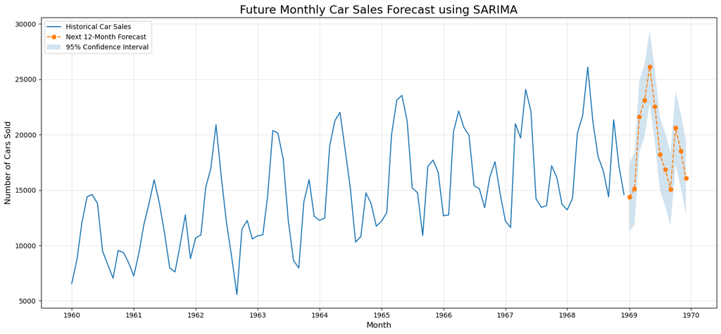

```python
plt.figure(figsize=(15, 7))

plt.plot(
    series.index,
    series,
    label="Historical Car Sales"
)

plt.plot(
    future_forecast.index,
    future_forecast,
    marker="o",
    linestyle="--",
    label="Next 12-Month Forecast"
)

plt.fill_between(
    future_confidence.index,
    future_confidence.iloc[:, 0],
    future_confidence.iloc[:, 1],
    alpha=0.2,
    label="95% Confidence Interval"
)

plt.title(
    "Future Monthly Car Sales Forecast using SARIMA",
    fontsize=17
)
plt.xlabel("Month", fontsize=12)
plt.ylabel("Number of Cars Sold", fontsize=12)
plt.legend()
plt.grid(alpha=0.3)
plt.tight_layout()
plt.show()
```

## ✅ 24. Conclusion

In this notebook, we successfully implemented the **SARIMA model** to forecast monthly car sales.

### Steps completed

- Loaded and inspected the Monthly Car Sales Dataset
- Converted the data into a proper time-series format
- Visualized historical sales
- Analysed rolling statistics
- Performed seasonal decomposition
- Checked stationarity using the ADF test
- Applied differencing
- Created a chronological train-test split
- Built and trained the SARIMA model
- Generated forecasts with confidence intervals
- Evaluated forecasts using MAE, RMSE and MAPE
- Forecasted car sales for the next 12 months

SARIMA is particularly effective for time-series data that contains both trend and repeating seasonal patterns.